# FJP Dados

#### MA_USOSUST

| Ano | N | Mínimo | Média | Mediana | Máximo | D. P. | C. V. | Zero | Missing |
| --- | --- | --- | --- | --- | --- | --- | --- | --- | --- |
| 2000 | 853 | 0 | 5,37 | 0 | 100 | 17,48 | 3,26 | 692 | 0 |
| 2001 | 853 | 0 | 6,24 | 0 | 100 | 18,18 | 2,91 | 669 | 0 |
| 2002 | 853 | 0 | 7,86 | 0 | 100 | 19,46 | 2,47 | 634 | 0 |
| 2003 | 853 | 0 | 9,21 | 0 | 100 | 20,62 | 2,24 | 602 | 0 |
| 2004 | 853 | 0 | 9,77 | 0 | 100 | 20,95 | 2,15 | 587 | 0 |
| 2005 | 853 | 0 | 9,01 | 0 | 100 | 20,48 | 2,27 | 599 | 0 |
| 2006 | 853 | 0 | 1,04 | 0 | 54,3 | 4,97 | 4,78 | 755 | 0 |
| 2007 | 853 | 0 | 8,39 | 0 | 100 | 20,18 | 2,4 | 614 | 0 |
| 2008 | 853 | 0 | 9,36 | 0 | 100 | 21,06 | 2,25 | 580 | 0 |
| 2009 | 853 | 0 | 9,36 | 0 | 100 | 21,06 | 2,25 | 580 | 0 |
| 2010 | 853 | 0 | 6,63 | 0 | 100 | 17,38 | 2,62 | 578 | 0 |
| 2011 | 853 | NA | NA | NA | NA | NA | NA | 0 | 853 |
| 2012 | 853 | NA | NA | NA | NA | NA | NA | 0 | 853 |
| 2013 | 853 | NA | NA | NA | NA | NA | NA | 0 | 853 |
| 2014 | 853 | NA | NA | NA | NA | NA | NA | 0 | 853 |
| 2015 | 853 | NA | NA | NA | NA | NA | NA | 0 | 853 |
| 2016 | 853 | NA | NA | NA | NA | NA | NA | 0 | 853 |
| 2017 | 853 | NA | NA | NA | NA | NA | NA | 0 | 853 |
| 2018 | 853 | NA | NA | NA | NA | NA | NA | 0 | 853 |
| 2019 | 853 | NA | NA | NA | NA | NA | NA | 0 | 853 |
| 2020 | 853 | NA | NA | NA | NA | NA | NA | 0 | 853 |
| 2021 | 853 | NA | NA | NA | NA | NA | NA | 0 | 853 |
| 2022 | 853 | NA | NA | NA | NA | NA | NA | 0 | 853 |

#### MA_ICMSECOLOG

| Ano | N | Mínimo | Média | Mediana | Máximo | D. P. | C. V. | Zero | Missing |
| --- | --- | --- | --- | --- | --- | --- | --- | --- | --- |
| 2000 | 853 | 0 | 47.290 | 0 | 2.189.575 | 213.868 | 4,52 | 626 | 0 |
| 2001 | 853 | 0 | 50.359 | 0 | 1.963.658 | 207.599 | 4,12 | 601 | 0 |
| 2002 | 853 | 0 | 46.919 | 0 | 1.426.089 | 163.850 | 3,49 | 569 | 0 |
| 2003 | 853 | 0 | 44.350 | 0 | 1.443.556 | 142.613 | 3,22 | 520 | 0 |
| 2004 | 853 | 0 | 47.920 | 0 | 840.504 | 119.109 | 2,49 | 486 | 0 |
| 2005 | 853 | 0 | 53.422 | 0 | 1.186.165 | 125.370 | 2,35 | 470 | 0 |
| 2006 | 853 | 0 | 57.314 | 0 | 966.761 | 126.267 | 2,2 | 459 | 0 |
| 2007 | 853 | 0 | 60.605 | 0 | 1.046.838 | 141.778 | 2,34 | 486 | 0 |
| 2008 | 853 | 0 | 64.368 | 0 | 1.011.226 | 149.285 | 2,32 | 464 | 0 |
| 2009 | 853 | 0 | 59.031 | 0 | 863.716 | 124.779 | 2,11 | 447 | 0 |
| 2010 | 853 | 0 | 68.109 | 13.075 | 3.114.531 | 164.509 | 2,42 | 325 | 0 |
| 2011 | 853 | 0 | 77.777 | 27.635 | 1.461.593 | 129.199 | 1,66 | 289 | 0 |
| 2012 | 853 | 0 | 84.049 | 45.657 | 1.467.101 | 134.072 | 1,6 | 278 | 0 |
| 2013 | 853 | 0 | 95.426 | 57.136 | 1.688.697 | 150.073 | 1,57 | 266 | 0 |
| 2014 | 853 | 0 | 100.566 | 54.059 | 1.719.298 | 154.991 | 1,54 | 263 | 0 |
| 2015 | 853 | 0 | 98.979 | 54.863 | 1.734.486 | 146.108 | 1,48 | 243 | 0 |
| 2016 | 853 | 0 | 107.731 | 67.062 | 1.816.397 | 154.576 | 1,43 | 243 | 0 |
| 2017 | 853 | 0 | 115.128 | 57.292 | 1.952.776 | 165.427 | 1,44 | 196 | 0 |
| 2018 | 853 | 0 | 113.850 | 66.404 | 1.914.329 | 160.321 | 1,41 | 211 | 0 |
| 2019 | 853 | 0 | 126.368 | 85.449 | 2.067.339 | 173.668 | 1,37 | 202 | 0 |
| 2020 | 853 | 0 | 132.823 | 99.067 | 2.152.925 | 180.193 | 1,36 | 184 | 0 |
| 2021 | 853 | 0 | 174.304 | 116.372 | 3.015.137 | 241.986 | 1,39 | 181 | 0 |
| 2022 | 853 | 0 | 183.185 | 117.985 | 3.260.185 | 258.747 | 1,41 | 164 | 0 |

#### MA_CRH

| Ano | N | Mínimo | Média | Mediana | Máximo | D. P. | C. V. | Zero | Missing |
| --- | --- | --- | --- | --- | --- | --- | --- | --- | --- |
| 2000 | 853 | NA | NA | NA | NA | NA | NA | 0 | 853 |
| 2001 | 853 | 0 | 115.814 | 0 | 4.835.546 | 496.663 | 4,29 | 729 | 0 |
| 2002 | 853 | 0 | 123.314 | 0 | 5.068.800 | 522.411 | 4,24 | 727 | 0 |
| 2003 | 853 | 0 | 137.601 | 0 | 5.692.625 | 580.263 | 4,22 | 722 | 0 |
| 2004 | 853 | 0 | 143.809 | 0 | 6.018.104 | 602.404 | 4,19 | 724 | 0 |
| 2005 | 853 | 0 | 169.525 | 0 | 6.575.222 | 701.362 | 4,14 | 723 | 0 |
| 2006 | 853 | 0 | 186.232 | 0 | 7.905.194 | 776.904 | 4,17 | 715 | 0 |
| 2007 | 853 | 0 | 145.084 | 0 | 7.708.796 | 680.559 | 4,69 | 739 | 0 |
| 2008 | 853 | 0 | 139.814 | 0 | 6.259.695 | 628.659 | 4,5 | 731 | 0 |
| 2009 | 853 | 0 | 113.341 | 0 | 6.452.832 | 521.402 | 4,6 | 736 | 0 |
| 2010 | 853 | 0 | 138.563 | 0 | 6.576.036 | 600.421 | 4,33 | 718 | 0 |
| 2011 | 853 | 0 | 140.643 | 0 | 6.255.415 | 596.043 | 4,24 | 716 | 0 |
| 2012 | 853 | 0 | 182.844 | 0 | 7.544.387 | 759.940 | 4,16 | 708 | 0 |
| 2013 | 853 | 0 | 174.562 | 0 | 8.729.094 | 732.971 | 4,2 | 704 | 0 |
| 2014 | 853 | 0 | 127.929 | 0 | 6.195.429 | 557.928 | 4,36 | 719 | 0 |
| 2015 | 853 | 0 | 119.357 | 0 | 5.694.042 | 498.656 | 4,18 | 702 | 6 |
| 2016 | 853 | 0 | 620.656 | 110.925 | 6.311.875 | 1.172.251 | 1,89 | 60 | 644 |
| 2017 | 853 | 0 | 759.859 | 258.913 | 5.622.628 | 1.171.516 | 1,54 | 2 | 700 |
| 2018 | 853 | 0 | 148.603 | 0 | 6.698.106 | 622.480 | 4,19 | 704 | 0 |
| 2019 | 853 | 0 | 221.384 | 0 | 8.369.906 | 910.664 | 4,11 | 701 | 0 |
| 2020 | 853 | 0 | 268.058 | 0 | 9.835.992 | 1.071.598 | 4 | 699 | 0 |
| 2021 | 853 | 0 | 211.819 | 0 | 7.391.148 | 826.664 | 3,9 | 697 | 0 |
| 2022 | 853 | 0 | 235.705 | 0 | 7.974.005 | 913.580 | 3,88 | 703 | 0 |

#### MA_CFEM

| Ano | N | Mínimo | Média | Mediana | Máximo | D. P. | C. V. | Zero | Missing |
| --- | --- | --- | --- | --- | --- | --- | --- | --- | --- |
| 2000 | 853 | NA | NA | NA | NA | NA | NA | 0 | 853 |
| 2001 | 853 | 0 | 172.343 | 0 | 45.170.277 | 1.804.881 | 10,47 | 654 | 0 |
| 2002 | 853 | NA | NA | NA | NA | NA | NA | 0 | 853 |
| 2003 | 853 | 0 | 267.744 | 0 | 65.232.308 | 2.710.137 | 10,12 | 618 | 0 |
| 2004 | 853 | 0 | 239.842 | 0 | 32.638.300 | 1.989.771 | 8,3 | 613 | 0 |
| 2005 | 853 | 0 | 323.323 | 0 | 5,8e+07 | 2.991.392 | 9,25 | 582 | 0 |
| 2006 | 853 | 0 | 371.555 | 0 | 68.677.475 | 3.627.242 | 9,76 | 547 | 0 |
| 2007 | 853 | 0 | 390.644 | 0 | 67.959.521 | 3.589.719 | 9,19 | 526 | 0 |
| 2008 | 853 | 0 | 594.717 | 0 | 88.757.326 | 5.465.901 | 9,19 | 509 | 0 |
| 2009 | 853 | 0 | 415.853 | 0 | 53.676.269 | 3.709.223 | 8,92 | 527 | 0 |
| 2010 | 853 | 0 | 658.533 | 0 | 85.464.496 | 5.625.662 | 8,54 | 501 | 0 |
| 2011 | 853 | 0 | 581.716 | 0 | 74.373.539 | 5.155.351 | 8,86 | 531 | 0 |
| 2012 | 853 | 0 | 762.210 | 0 | 126.510.101 | 7.126.221 | 9,35 | 499 | 0 |
| 2013 | 853 | 0 | 899.355 | 0 | 150.377.100 | 8.606.080 | 9,57 | 495 | 0 |
| 2014 | 853 | 0 | 629.417 | 0 | 72.159.142 | 5.217.641 | 8,29 | 468 | 0 |
| 2015 | 853 | 0 | 490.309 | 0 | 61.562.086 | 3.899.000 | 7,95 | 437 | 6 |
| 2016 | 853 | 0 | 1.157.445 | 7.206 | 92.575.131 | 7.407.292 | 6,4 | 93 | 353 |
| 2017 | 853 | 0 | 1.087.306 | 15.194 | 65.614.321 | 6.114.133 | 5,62 | 5 | 391 |
| 2018 | 853 | 0 | 879.499 | 66,24 | 98.920.171 | 7.315.550 | 8,32 | 419 | 0 |
| 2019 | 853 | 0 | 1.379.841 | 303,9 | 172.335.313 | 10.800.331 | 7,83 | 391 | 0 |
| 2020 | 853 | 0 | 1.751.449 | 2.575 | 201.430.728 | 12.953.125 | 7,4 | 312 | 0 |
| 2021 | 853 | 0 | 3.132.376 | 2.787 | 387.309.733 | 25.713.535 | 8,21 | 292 | 0 |
| 2022 | 853 | 0 | 2.266.239 | 4.651 | 2,42e+08 | 16.624.856 | 7,34 | 270 | 0 |

#### MA_FOCOS

| Ano | N | Mínimo | Média | Mediana | Máximo | D. P. | C. V. | Zero | Missing |
| --- | --- | --- | --- | --- | --- | --- | --- | --- | --- |
| 2000 | 853 | 0 | 0,12 | 0,04 | 2,98 | 0,26 | 2,24 | 304 | 0 |
| 2001 | 853 | 0 | 0,12 | 0,04 | 3,43 | 0,26 | 2,19 | 151 | 0 |
| 2002 | 853 | 0 | 0,12 | 0,04 | 2,23 | 0,21 | 1,84 | 103 | 0 |
| 2003 | 853 | 0 | 0,12 | 0,04 | 1,53 | 0,2 | 1,71 | 98 | 0 |
| 2004 | 853 | 0 | 0,12 | 0,03 | 3,3 | 0,26 | 2,24 | 147 | 0 |
| 2005 | 853 | 0 | 0,12 | 0,02 | 2,36 | 0,25 | 2,16 | 196 | 0 |
| 2006 | 853 | 0 | 0,12 | 0,04 | 2,61 | 0,23 | 1,98 | 97 | 0 |
| 2007 | 853 | 0 | 0,12 | 0,04 | 2,24 | 0,22 | 1,88 | 108 | 0 |
| 2008 | 853 | 0 | 0,12 | 0,02 | 2,5 | 0,25 | 2,14 | 182 | 0 |
| 2009 | 853 | 0 | 0,12 | 0,02 | 2,9 | 0,27 | 2,33 | 212 | 0 |
| 2010 | 853 | 0 | 0,12 | 0,04 | 2,29 | 0,25 | 2,1 | 119 | 0 |
| 2011 | 853 | 0 | 0,12 | 0,05 | 2,21 | 0,21 | 1,78 | 72 | 0 |
| 2012 | 853 | 0 | 0,12 | 0,03 | 3,54 | 0,28 | 2,41 | 149 | 0 |
| 2013 | 853 | 0 | 0,12 | 0,04 | 1,99 | 0,22 | 1,89 | 107 | 0 |
| 2014 | 853 | 0 | 0,12 | 0,05 | 2,38 | 0,21 | 1,79 | 64 | 0 |
| 2015 | 853 | 0 | 0,12 | 0,03 | 2,22 | 0,23 | 1,98 | 155 | 0 |
| 2016 | 853 | 0 | 0,12 | 0,04 | 2,83 | 0,24 | 2,09 | 65 | 0 |
| 2017 | 853 | 0 | 0,12 | 0,05 | 2,08 | 0,21 | 1,79 | 74 | 0 |
| 2018 | 853 | 0 | 0,12 | 0,04 | 2,06 | 0,24 | 1,99 | 77 | 36 |
| 2019 | 853 | 0 | 0,12 | 0,05 | 1,69 | 0,19 | 1,65 | 60 | 0 |
| 2020 | 853 | 0 | 0,12 | 0,04 | 2,68 | 0,25 | 2,15 | 11 | 0 |
| 2021 | 853 | 0 | 0,12 | 0,05 | 2,2 | 0,22 | 1,88 | 115 | 0 |
| 2022 | 853 | 0 | 0,12 | 0,04 | 2,03 | 0,21 | 1,83 | 178 | 0 |

#### MA_CANA

| Ano | N | Mínimo | Média | Mediana | Máximo | D. P. | C. V. | Zero | Missing |
| --- | --- | --- | --- | --- | --- | --- | --- | --- | --- |
| 2000 | 853 | 0 | 0,75 | 0,14 | 63,64 | 3,43 | 4,59 | 106 | 0 |
| 2001 | 853 | 0 | 0,73 | 0,13 | 63,64 | 3,44 | 4,7 | 122 | 0 |
| 2002 | 853 | 0 | 0,67 | 0,14 | 31,13 | 2,71 | 4,04 | 122 | 0 |
| 2003 | 853 | 0 | 0,68 | 0,13 | 28,81 | 2,69 | 3,93 | 127 | 0 |
| 2004 | 853 | 0 | 0,75 | 0,13 | 31,37 | 2,94 | 3,94 | 129 | 0 |
| 2005 | 853 | 0 | 0,75 | 0,14 | 28,81 | 2,89 | 3,84 | 125 | 0 |
| 2006 | 853 | 0 | 0,89 | 0,14 | 58,74 | 3,65 | 4,12 | 119 | 0 |
| 2007 | 853 | 0 | 0,98 | 0,14 | 58,74 | 3,92 | 4 | 117 | 0 |
| 2008 | 853 | 0 | 1,1 | 0,15 | 58,74 | 4,19 | 3,8 | 108 | 0 |
| 2009 | 853 | 0 | 1,17 | 0,15 | 41,67 | 4,11 | 3,52 | 116 | 0 |
| 2010 | 853 | 0 | 1,19 | 0,16 | 41,67 | 4,17 | 3,5 | 113 | 0 |
| 2011 | 853 | 0 | 1,31 | 0,16 | 71,81 | 4,81 | 3,67 | 103 | 0 |
| 2012 | 853 | 0 | 1,34 | 0,17 | 71,81 | 4,94 | 3,68 | 107 | 0 |
| 2013 | 853 | 0 | 1,33 | 0,17 | 71,81 | 4,93 | 3,7 | 116 | 0 |
| 2014 | 853 | 0 | 1,24 | 0,16 | 40,14 | 4,34 | 3,49 | 175 | 0 |
| 2015 | 853 | 0 | 1,2 | 0,15 | 39,95 | 4,14 | 3,45 | 167 | 0 |
| 2016 | 853 | 0 | 1,19 | 0,14 | 52,78 | 4,47 | 3,74 | 169 | 0 |
| 2017 | 853 | 0 | 1,1 | 0,08 | 51,28 | 4,36 | 3,97 | 119 | 0 |
| 2018 | 853 | 0 | 1,08 | 0,08 | 42,1 | 4,32 | 4 | 112 | 0 |
| 2019 | 853 | 0 | 1,12 | 0,08 | 42,25 | 4,45 | 3,96 | 118 | 0 |
| 2020 | 853 | 0 | 1,19 | 0,09 | 51,86 | 4,71 | 3,96 | 98 | 0 |
| 2021 | 853 | 0 | 1,12 | 0,06 | 49,74 | 4,63 | 4,12 | 193 | 0 |
| 2022 | 853 | 0 | 1,09 | 0,05 | 45,72 | 4,5 | 4,14 | 204 | 0 |

#### MA_FROTA

| Ano | N | Mínimo | Média | Mediana | Máximo | D. P. | C. V. | Zero | Missing |
| --- | --- | --- | --- | --- | --- | --- | --- | --- | --- |
| 2000 | 853 | NA | NA | NA | NA | NA | NA | 0 | 853 |
| 2001 | 853 | 0,01 | 10,45 | 2,48 | 2.139 | 78,38 | 7,5 | 0 | 0 |
| 2002 | 853 | 0,02 | 11,19 | 2,65 | 2.247 | 82,64 | 7,39 | 0 | 0 |
| 2003 | 853 | 0,02 | 12 | 2,86 | 2.372 | 87,43 | 7,29 | 0 | 0 |
| 2004 | 853 | 0,02 | 12,83 | 3,13 | 2.471 | 91,57 | 7,14 | 0 | 0 |
| 2005 | 853 | 0,03 | 13,82 | 3,42 | 2.598 | 96,85 | 7,01 | 0 | 0 |
| 2006 | 853 | 0,03 | 15,03 | 3,72 | 2.810 | 104,7 | 6,97 | 0 | 0 |
| 2007 | 853 | 0,04 | 16,65 | 4,13 | 3.084 | 115,1 | 6,91 | 0 | 0 |
| 2008 | 853 | 0,06 | 18,51 | 4,64 | 3.400 | 127,2 | 6,87 | 0 | 0 |
| 2009 | 853 | 0,07 | 20,34 | 5,12 | 3.718 | 139,3 | 6,85 | 0 | 0 |
| 2010 | 853 | 0,08 | 22,39 | 5,63 | 4.058 | 152,2 | 6,8 | 0 | 0 |
| 2011 | 853 | 0,09 | 24,57 | 6,23 | 4.357 | 164,3 | 6,69 | 0 | 0 |
| 2012 | 853 | 0,11 | 26,66 | 6,89 | 4.601 | 174,6 | 6,55 | 0 | 0 |
| 2013 | 853 | 0,12 | 28,63 | 7,53 | 4.833 | 184,2 | 6,43 | 0 | 0 |
| 2014 | 853 | 0,13 | 30,44 | 8,12 | 5.040 | 192,5 | 6,32 | 0 | 0 |
| 2015 | 853 | 0,13 | 31,88 | 8,55 | 5.191 | 198,6 | 6,23 | 0 | 0 |
| 2016 | 853 | 0,14 | 33,23 | 8,95 | 5.402 | 206,4 | 6,21 | 0 | 0 |
| 2017 | 853 | 0,15 | 34,69 | 9,43 | 5.777 | 219,1 | 6,32 | 0 | 0 |
| 2018 | 853 | 0,15 | 36,36 | 9,72 | 6.286 | 236 | 6,49 | 0 | 0 |
| 2019 | 853 | 0,16 | 38,17 | 10,11 | 6.903 | 256,3 | 6,71 | 0 | 0 |
| 2020 | 853 | 0,17 | 39,43 | 10,68 | 6.888 | 257 | 6,52 | 0 | 0 |
| 2021 | 853 | 0,17 | 40,98 | 11,23 | 7.212 | 268 | 6,54 | 0 | 0 |
| 2022 | 853 | 0,19 | 42,51 | 11,75 | 7.844 | 288 | 6,77 | 0 | 0 |

#### MA_BOVINO

| Ano | N | Mínimo | Média | Mediana | Máximo | D. P. | C. V. | Zero | Missing |
| --- | --- | --- | --- | --- | --- | --- | --- | --- | --- |
| 2000 | 853 | 0 | 38,07 | 37,81 | 121,6 | 19,45 | 0,51 | 2 | 0 |
| 2001 | 853 | 0 | 38,26 | 37,74 | 122,1 | 19,69 | 0,51 | 2 | 0 |
| 2002 | 853 | 0 | 38,65 | 37,92 | 131,2 | 20,29 | 0,52 | 2 | 0 |
| 2003 | 853 | 0 | 38,55 | 37,56 | 135,1 | 20,58 | 0,53 | 1 | 0 |
| 2004 | 853 | 0 | 39,96 | 38,62 | 148,4 | 20,94 | 0,52 | 1 | 0 |
| 2005 | 853 | 1,87 | 39,61 | 37,75 | 279,1 | 22,39 | 0,57 | 0 | 0 |
| 2006 | 853 | 2,71 | 41,76 | 39,85 | 189,7 | 22,06 | 0,53 | 0 | 0 |
| 2007 | 853 | 2,63 | 42,33 | 40,36 | 127,5 | 21,51 | 0,51 | 0 | 0 |
| 2008 | 853 | 2,33 | 42,26 | 40,4 | 125,7 | 21,45 | 0,51 | 0 | 0 |
| 2009 | 853 | 2,19 | 42,92 | 41,32 | 124 | 21,47 | 0,5 | 0 | 0 |
| 2010 | 853 | 1,92 | 43,06 | 41,39 | 119 | 21,54 | 0,5 | 0 | 0 |
| 2011 | 853 | 1,89 | 45,11 | 43,56 | 138 | 22,77 | 0,5 | 0 | 0 |
| 2012 | 853 | 1,75 | 45,2 | 44,07 | 145,4 | 22,97 | 0,51 | 0 | 0 |
| 2013 | 853 | 1,63 | 45,97 | 44,63 | 147,9 | 23,67 | 0,51 | 0 | 0 |
| 2014 | 853 | 1,59 | 45,03 | 44,09 | 134,1 | 23,49 | 0,52 | 0 | 0 |
| 2015 | 853 | 1,37 | 45,51 | 43,88 | 138,6 | 24,27 | 0,53 | 0 | 0 |
| 2016 | 853 | 1,42 | 46,2 | 44,8 | 133,2 | 24,68 | 0,53 | 0 | 0 |
| 2017 | 853 | 1,48 | 44,24 | 43,4 | 122,2 | 22,71 | 0,51 | 0 | 0 |
| 2018 | 853 | 1,19 | 43,94 | 42,84 | 126,1 | 22,64 | 0,52 | 0 | 0 |
| 2019 | 853 | 1,23 | 44,37 | 43,27 | 126,7 | 22,87 | 0,52 | 0 | 0 |
| 2020 | 853 | 0,67 | 44,37 | 43,33 | 136,5 | 22,97 | 0,52 | 0 | 0 |
| 2021 | 853 | 0,68 | 45,67 | 44,28 | 160,3 | 23,68 | 0,52 | 0 | 0 |
| 2022 | 853 | 0,72 | 45,69 | 44,05 | 151,7 | 23,71 | 0,52 | 0 | 0 |

#### MA_REFLO

| Ano | N | Mínimo | Média | Mediana | Máximo | D. P. | C. V. | Zero | Missing |
| --- | --- | --- | --- | --- | --- | --- | --- | --- | --- |
| 2000 | 853 | 0 | 1,08 | 0,07 | 21,71 | 2,69 | 2,48 | 182 | 0 |
| 2001 | 853 | 0 | 1,12 | 0,09 | 21,32 | 2,73 | 2,45 | 173 | 0 |
| 2002 | 853 | 0 | 1,14 | 0,1 | 21,16 | 2,77 | 2,42 | 162 | 0 |
| 2003 | 853 | 0 | 1,17 | 0,1 | 21,22 | 2,84 | 2,42 | 156 | 0 |
| 2004 | 853 | 0 | 1,23 | 0,11 | 21,98 | 2,92 | 2,37 | 153 | 0 |
| 2005 | 853 | 0 | 1,29 | 0,13 | 22,2 | 2,99 | 2,32 | 145 | 0 |
| 2006 | 853 | 0 | 1,4 | 0,19 | 22,28 | 3,12 | 2,23 | 134 | 0 |
| 2007 | 853 | 0 | 1,5 | 0,25 | 24,1 | 3,24 | 2,15 | 117 | 0 |
| 2008 | 853 | 0 | 1,65 | 0,37 | 25,15 | 3,37 | 2,03 | 97 | 0 |
| 2009 | 853 | 0 | 1,83 | 0,49 | 25,81 | 3,48 | 1,91 | 87 | 0 |
| 2010 | 853 | 0 | 1,99 | 0,58 | 25,99 | 3,6 | 1,8 | 76 | 0 |
| 2011 | 853 | 0 | 2,15 | 0,71 | 26,25 | 3,7 | 1,72 | 68 | 0 |
| 2012 | 853 | 0 | 2,31 | 0,82 | 26,42 | 3,81 | 1,65 | 60 | 0 |
| 2013 | 853 | 0 | 2,42 | 0,89 | 26,52 | 3,9 | 1,61 | 59 | 0 |
| 2014 | 853 | 0 | 2,47 | 0,92 | 27,27 | 3,97 | 1,61 | 61 | 0 |
| 2015 | 853 | 0 | 2,5 | 0,93 | 27,32 | 4 | 1,6 | 59 | 0 |
| 2016 | 853 | 0 | 2,63 | 0,97 | 27,67 | 4,2 | 1,6 | 55 | 0 |
| 2017 | 853 | 0 | 2,7 | 1 | 27,78 | 4,27 | 1,58 | 54 | 0 |
| 2018 | 853 | 0 | 2,72 | 1,02 | 27,8 | 4,29 | 1,57 | 53 | 0 |
| 2019 | 853 | 0 | 2,78 | 1,1 | 27,95 | 4,34 | 1,56 | 48 | 0 |
| 2020 | 853 | 0 | 2,28 | 0,89 | 26,04 | 3,62 | 1,58 | 47 | 0 |
| 2021 | 853 | 0 | 2,36 | 0,9 | 26,7 | 3,73 | 1,58 | 45 | 1 |
| 2022 | 853 | 0 | 2,4 | 0,95 | 26,81 | 3,77 | 1,57 | 47 | 0 |

#### MA_FLONATIVA

| Ano | N | Mínimo | Média | Mediana | Máximo | D. P. | C. V. | Zero | Missing |
| --- | --- | --- | --- | --- | --- | --- | --- | --- | --- |
| 2000 | 853 | 4,81 | 32,98 | 25,82 | 98,08 | 20,21 | 0,61 | 0 | 0 |
| 2001 | 853 | 4,69 | 33,05 | 25,91 | 98,04 | 20,2 | 0,61 | 0 | 0 |
| 2002 | 853 | 4,59 | 32,93 | 25,89 | 97,94 | 20,15 | 0,61 | 0 | 0 |
| 2003 | 853 | 4,4 | 32,87 | 25,87 | 97,91 | 19,94 | 0,61 | 0 | 0 |
| 2004 | 853 | 4,62 | 32,93 | 25,94 | 97,97 | 19,75 | 0,6 | 0 | 0 |
| 2005 | 853 | 4,73 | 32,97 | 26,03 | 97,94 | 19,71 | 0,6 | 0 | 0 |
| 2006 | 853 | 4,99 | 33,03 | 26,35 | 97,69 | 19,62 | 0,59 | 0 | 0 |
| 2007 | 853 | 5,22 | 33,19 | 26,69 | 97,55 | 19,46 | 0,59 | 0 | 0 |
| 2008 | 853 | 5,22 | 33,28 | 26,85 | 97,34 | 19,34 | 0,58 | 0 | 0 |
| 2009 | 853 | 5,18 | 33,47 | 27,21 | 97,11 | 19,16 | 0,57 | 0 | 0 |
| 2010 | 853 | 5,37 | 33,69 | 27,89 | 97,16 | 19 | 0,56 | 0 | 0 |
| 2011 | 853 | 5,59 | 33,92 | 28,19 | 97,1 | 18,89 | 0,56 | 0 | 0 |
| 2012 | 853 | 5,59 | 34 | 28,15 | 97,02 | 18,81 | 0,55 | 0 | 0 |
| 2013 | 853 | 5,56 | 33,8 | 27,8 | 96,82 | 18,58 | 0,55 | 0 | 0 |
| 2014 | 853 | 5,65 | 33,78 | 27,98 | 96,78 | 18,44 | 0,55 | 0 | 0 |
| 2015 | 853 | 5,51 | 33,79 | 28,24 | 96,32 | 18,37 | 0,54 | 0 | 0 |
| 2016 | 853 | 5,45 | 33,71 | 28 | 96,29 | 18,32 | 0,54 | 0 | 0 |
| 2017 | 853 | 5,24 | 33,69 | 27,84 | 96,31 | 18,35 | 0,54 | 0 | 0 |
| 2018 | 853 | 5,55 | 33,87 | 28,06 | 96,43 | 18,37 | 0,54 | 0 | 0 |
| 2019 | 853 | 5,49 | 33,28 | 27,48 | 96,38 | 18,24 | 0,55 | 0 | 0 |
| 2020 | 853 | 4,47 | 32,41 | 26,34 | 97,43 | 18,07 | 0,56 | 0 | 0 |
| 2021 | 853 | 3,59 | 31,93 | 25,75 | 97,61 | 18,76 | 0,59 | 0 | 1 |
| 2022 | 853 | 3,82 | 29,39 | 23,64 | 95,76 | 17,31 | 0,59 | 0 | 0 |

#### MA_INFRA

| Ano | N | Mínimo | Média | Mediana | Máximo | D. P. | C. V. | Zero | Missing |
| --- | --- | --- | --- | --- | --- | --- | --- | --- | --- |
| 2000 | 853 | 0 | 0,84 | 0,16 | 78,88 | 3,94 | 4,69 | 39 | 0 |
| 2001 | 853 | 0 | 0,86 | 0,17 | 79,21 | 3,99 | 4,62 | 32 | 0 |
| 2002 | 853 | 0 | 0,89 | 0,18 | 79,5 | 4,05 | 4,56 | 31 | 0 |
| 2003 | 853 | 0 | 0,9 | 0,18 | 79,59 | 4,07 | 4,53 | 30 | 0 |
| 2004 | 853 | 0 | 0,91 | 0,18 | 79,58 | 4,08 | 4,5 | 27 | 0 |
| 2005 | 853 | 0 | 0,91 | 0,18 | 79,59 | 4,08 | 4,47 | 26 | 0 |
| 2006 | 853 | 0 | 0,93 | 0,18 | 79,93 | 4,14 | 4,43 | 22 | 0 |
| 2007 | 853 | 0 | 0,96 | 0,2 | 80,32 | 4,19 | 4,38 | 20 | 0 |
| 2008 | 853 | 0 | 0,96 | 0,2 | 80,33 | 4,19 | 4,37 | 19 | 0 |
| 2009 | 853 | 0 | 1 | 0,21 | 80,63 | 4,26 | 4,26 | 10 | 0 |
| 2010 | 853 | 0 | 1,02 | 0,22 | 80,86 | 4,31 | 4,22 | 10 | 0 |
| 2011 | 853 | 0 | 1,05 | 0,23 | 81,18 | 4,39 | 4,18 | 9 | 0 |
| 2012 | 853 | 0 | 1,07 | 0,23 | 81,32 | 4,43 | 4,14 | 8 | 0 |
| 2013 | 853 | 0 | 1,11 | 0,24 | 81,62 | 4,52 | 4,06 | 9 | 0 |
| 2014 | 853 | 0 | 1,14 | 0,25 | 81,81 | 4,57 | 4,03 | 9 | 0 |
| 2015 | 853 | 0 | 1,15 | 0,25 | 82,06 | 4,61 | 3,99 | 9 | 0 |
| 2016 | 853 | 0 | 1,17 | 0,26 | 82,12 | 4,63 | 3,96 | 8 | 0 |
| 2017 | 853 | 0 | 1,17 | 0,26 | 82,12 | 4,63 | 3,96 | 8 | 0 |
| 2018 | 853 | 0 | 1,2 | 0,26 | 82,26 | 4,68 | 3,9 | 8 | 0 |
| 2019 | 853 | 0 | 1,22 | 0,28 | 82,27 | 4,69 | 3,85 | 6 | 0 |
| 2020 | 853 | 0 | 1,42 | 0,39 | 83,02 | 4,94 | 3,47 | 2 | 0 |
| 2021 | 853 | 0 | 1,37 | 0,37 | 81,14 | 4,73 | 3,46 | 8 | 1 |
| 2022 | 853 | 0,02 | 1,34 | 0,39 | 80,67 | 4,65 | 3,46 | 0 | 0 |

#### MA_AGRO

| Ano | N | Mínimo | Média | Mediana | Máximo | D. P. | C. V. | Zero | Missing |
| --- | --- | --- | --- | --- | --- | --- | --- | --- | --- |
| 2000 | 853 | 1,73 | 63,97 | 71,16 | 95,04 | 21,19 | 0,33 | 0 | 0 |
| 2001 | 853 | 1,77 | 63,84 | 71,21 | 95,24 | 21,18 | 0,33 | 0 | 0 |
| 2002 | 853 | 1,83 | 63,9 | 71,43 | 95,31 | 21,14 | 0,33 | 0 | 0 |
| 2003 | 853 | 1,87 | 63,9 | 71,08 | 95,51 | 20,96 | 0,33 | 0 | 0 |
| 2004 | 853 | 1,81 | 63,74 | 70,86 | 95,23 | 20,82 | 0,33 | 0 | 0 |
| 2005 | 853 | 1,84 | 63,63 | 70,68 | 95,12 | 20,8 | 0,33 | 0 | 0 |
| 2006 | 853 | 2,07 | 63,44 | 70,33 | 94,81 | 20,77 | 0,33 | 0 | 0 |
| 2007 | 853 | 2,15 | 63,14 | 69,79 | 94,59 | 20,64 | 0,33 | 0 | 0 |
| 2008 | 853 | 2,21 | 62,9 | 69,33 | 94,62 | 20,57 | 0,33 | 0 | 0 |
| 2009 | 853 | 2,32 | 62,5 | 68,82 | 94,62 | 20,43 | 0,33 | 0 | 0 |
| 2010 | 853 | 2,14 | 62,09 | 68,06 | 94,45 | 20,3 | 0,33 | 0 | 0 |
| 2011 | 853 | 2,11 | 61,68 | 67,93 | 94,21 | 20,23 | 0,33 | 0 | 0 |
| 2012 | 853 | 2,15 | 61,44 | 67,7 | 94,22 | 20,18 | 0,33 | 0 | 0 |
| 2013 | 853 | 2,38 | 61,5 | 67,53 | 94,27 | 20,03 | 0,33 | 0 | 0 |
| 2014 | 853 | 2,59 | 61,49 | 67,35 | 94,16 | 19,93 | 0,32 | 0 | 0 |
| 2015 | 853 | 2,87 | 61,44 | 67,16 | 93,77 | 19,89 | 0,32 | 0 | 0 |
| 2016 | 853 | 2,84 | 61,37 | 67,02 | 93,27 | 19,97 | 0,33 | 0 | 0 |
| 2017 | 853 | 2,75 | 61,31 | 67,35 | 92,53 | 20 | 0,33 | 0 | 0 |
| 2018 | 853 | 2,62 | 61,06 | 67,19 | 92,33 | 19,99 | 0,33 | 0 | 0 |
| 2019 | 853 | 2,67 | 61,57 | 67,68 | 92,42 | 19,89 | 0,32 | 0 | 0 |
| 2020 | 853 | 2,34 | 62,72 | 69,06 | 92,25 | 19,55 | 0,31 | 0 | 0 |
| 2021 | 853 | 2,11 | 63,12 | 69,32 | 93,16 | 20,29 | 0,32 | 0 | 1 |
| 2022 | 853 | 3,98 | 65,43 | 71,67 | 92,31 | 18,82 | 0,29 | 0 | 0 |

### Quantil

#### MA_MATLANTICA

| Ano | 25% | 75% |
| --- | --- | --- |
| 2000 | NA | NA |
| 2001 | NA | NA |
| 2002 | NA | NA |
| 2003 | 5,3 | 18,2 |
| 2004 | 5,3 | 18,2 |
| 2005 | 5,2 | 17,8 |
| 2006 | 5,2 | 17,8 |
| 2007 | 5,2 | 17,8 |
| 2008 | 5,2 | 17,8 |
| 2009 | 5,2 | 17,8 |
| 2010 | 5,2 | 17,8 |
| 2011 | NA | NA |
| 2012 | NA | NA |
| 2013 | NA | NA |
| 2014 | NA | NA |
| 2015 | NA | NA |
| 2016 | NA | NA |
| 2017 | NA | NA |
| 2018 | NA | NA |
| 2019 | NA | NA |
| 2020 | NA | NA |
| 2021 | NA | NA |
| 2022 | NA | NA |

#### MA_AIIGENA

| Ano | 25% | 75% |
| --- | --- | --- |
| 2000 | 0 | 0 |
| 2001 | 0 | 0 |
| 2002 | 0 | 0 |
| 2003 | 0 | 0 |
| 2004 | 0 | 0 |
| 2005 | 0 | 0 |
| 2006 | 0 | 0 |
| 2007 | 0 | 0 |
| 2008 | 0 | 0 |
| 2009 | 0 | 0 |
| 2010 | 0 | 0 |
| 2011 | NA | NA |
| 2012 | NA | NA |
| 2013 | NA | NA |
| 2014 | NA | NA |
| 2015 | NA | NA |
| 2016 | NA | NA |
| 2017 | NA | NA |
| 2018 | NA | NA |
| 2019 | NA | NA |
| 2020 | NA | NA |
| 2021 | NA | NA |
| 2022 | NA | NA |

#### MA_PROINTEGRAL

| Ano | 25% | 75% |
| --- | --- | --- |
| 2000 | 0 | 0 |
| 2001 | 0 | 0 |
| 2002 | 0 | 0 |
| 2003 | 0 | 0 |
| 2004 | 0 | 0 |
| 2005 | 0 | 0 |
| 2006 | 0 | 0 |
| 2007 | 0 | 0 |
| 2008 | 0 | 0 |
| 2009 | 0 | 0 |
| 2010 | 0 | 0 |
| 2011 | NA | NA |
| 2012 | NA | NA |
| 2013 | NA | NA |
| 2014 | NA | NA |
| 2015 | NA | NA |
| 2016 | NA | NA |
| 2017 | NA | NA |
| 2018 | NA | NA |
| 2019 | NA | NA |
| 2020 | NA | NA |
| 2021 | NA | NA |
| 2022 | NA | NA |

#### MA_USOSUST

| Ano | 25% | 75% |
| --- | --- | --- |
| 2000 | 0 | 0 |
| 2001 | 0 | 0 |
| 2002 | 0 | 0,1 |
| 2003 | 0 | 0,9 |
| 2004 | 0 | 3 |
| 2005 | 0 | 0,5 |
| 2006 | 0 | 0 |
| 2007 | 0 | 0,2 |
| 2008 | 0 | 1,1 |
| 2009 | 0 | 1,1 |
| 2010 | 0 | 1,2 |
| 2011 | NA | NA |
| 2012 | NA | NA |
| 2013 | NA | NA |
| 2014 | NA | NA |
| 2015 | NA | NA |
| 2016 | NA | NA |
| 2017 | NA | NA |
| 2018 | NA | NA |
| 2019 | NA | NA |
| 2020 | NA | NA |
| 2021 | NA | NA |
| 2022 | NA | NA |

#### MA_ICMSECOLOG

| Ano | 25% | 75% |
| --- | --- | --- |
| 2000 | 0 | 445,5 |
| 2001 | 0 | 2.044 |
| 2002 | 0 | 5.624 |
| 2003 | 0 | 15.222 |
| 2004 | 0 | 30.679 |
| 2005 | 0 | 50.677 |
| 2006 | 0 | 52.213 |
| 2007 | 0 | 45.981 |
| 2008 | 0 | 49.729 |
| 2009 | 0 | 55.854 |
| 2010 | 0 | 75.744 |
| 2011 | 0 | 114.969 |
| 2012 | 0 | 115.833 |
| 2013 | 0 | 141.888 |
| 2014 | 0 | 152.293 |
| 2015 | 0 | 144.246 |
| 2016 | 0 | 142.985 |
| 2017 | 1.309 | 156.965 |
| 2018 | 242,7 | 140.336 |
| 2019 | 1.078 | 154.698 |
| 2020 | 3.966 | 170.522 |
| 2021 | 7.832 | 211.880 |
| 2022 | 32.093 | 203.281 |

#### MA_CRH

| Ano | 25% | 75% |
| --- | --- | --- |
| 2000 | NA | NA |
| 2001 | 0 | 0 |
| 2002 | 0 | 0 |
| 2003 | 0 | 0 |
| 2004 | 0 | 0 |
| 2005 | 0 | 0 |
| 2006 | 0 | 0 |
| 2007 | 0 | 0 |
| 2008 | 0 | 0 |
| 2009 | 0 | 0 |
| 2010 | 0 | 0 |
| 2011 | 0 | 0 |
| 2012 | 0 | 0 |
| 2013 | 0 | 0 |
| 2014 | 0 | 0 |
| 2015 | 0 | 0 |
| 2016 | 0 | 608.758 |
| 2017 | 76.022 | 881.070 |
| 2018 | 0 | 0 |
| 2019 | 0 | 0 |
| 2020 | 0 | 0 |
| 2021 | 0 | 0 |
| 2022 | 0 | 0 |

#### MA_CFEM

| Ano | 25% | 75% |
| --- | --- | --- |
| 2000 | NA | NA |
| 2001 | 0 | 0 |
| 2002 | NA | NA |
| 2003 | 0 | 298,6 |
| 2004 | 0 | 458,4 |
| 2005 | 0 | 848,6 |
| 2006 | 0 | 1.392 |
| 2007 | 0 | 2.279 |
| 2008 | 0 | 3.536 |
| 2009 | 0 | 3.022 |
| 2010 | 0 | 5.374 |
| 2011 | 0 | 3.648 |
| 2012 | 0 | 7.214 |
| 2013 | 0 | 8.283 |
| 2014 | 0 | 12.647 |
| 2015 | 0 | 12.286 |
| 2016 | 335 | 60.077 |
| 2017 | 2.629 | 95.202 |
| 2018 | 0 | 10.708 |
| 2019 | 0 | 30.180 |
| 2020 | 0 | 95.468 |
| 2021 | 0 | 61.198 |
| 2022 | 0 | 90.785 |

#### MA_FOCOS

| Ano | 25% | 75% |
| --- | --- | --- |
| 2000 | 0 | 0,1 |
| 2001 | 0,01 | 0,11 |
| 2002 | 0,01 | 0,12 |
| 2003 | 0,01 | 0,13 |
| 2004 | 0,01 | 0,1 |
| 2005 | 0,01 | 0,1 |
| 2006 | 0,02 | 0,12 |
| 2007 | 0,01 | 0,11 |
| 2008 | 0,01 | 0,1 |
| 2009 | 0,01 | 0,09 |
| 2010 | 0,01 | 0,1 |
| 2011 | 0,02 | 0,12 |
| 2012 | 0,01 | 0,09 |
| 2013 | 0,01 | 0,11 |
| 2014 | 0,02 | 0,13 |
| 2015 | 0,01 | 0,12 |
| 2016 | 0,02 | 0,11 |
| 2017 | 0,02 | 0,11 |
| 2018 | 0,01 | 0,11 |
| 2019 | 0,02 | 0,14 |
| 2020 | 0,01 | 0,11 |
| 2021 | 0,02 | 0,12 |
| 2022 | 0,01 | 0,13 |

#### MA_CANA

| Ano | 25% | 75% |
| --- | --- | --- |
| 2000 | 0,04 | 0,38 |
| 2001 | 0,04 | 0,37 |
| 2002 | 0,04 | 0,37 |
| 2003 | 0,04 | 0,35 |
| 2004 | 0,04 | 0,36 |
| 2005 | 0,04 | 0,37 |
| 2006 | 0,04 | 0,4 |
| 2007 | 0,04 | 0,41 |
| 2008 | 0,05 | 0,43 |
| 2009 | 0,04 | 0,47 |
| 2010 | 0,04 | 0,45 |
| 2011 | 0,05 | 0,52 |
| 2012 | 0,05 | 0,53 |
| 2013 | 0,04 | 0,52 |
| 2014 | 0,03 | 0,5 |
| 2015 | 0,03 | 0,48 |
| 2016 | 0,03 | 0,44 |
| 2017 | 0,02 | 0,25 |
| 2018 | 0,02 | 0,23 |
| 2019 | 0,02 | 0,26 |
| 2020 | 0,02 | 0,27 |
| 2021 | 0,01 | 0,2 |
| 2022 | 0 | 0,17 |

#### MA_FROTA

| Ano | 25% | 75% |
| --- | --- | --- |
| 2000 | NA | NA |
| 2001 | 0,79 | 5,79 |
| 2002 | 0,91 | 6,16 |
| 2003 | 1,01 | 6,76 |
| 2004 | 1,14 | 7,35 |
| 2005 | 1,29 | 7,79 |
| 2006 | 1,44 | 8,42 |
| 2007 | 1,63 | 9,25 |
| 2008 | 1,84 | 10,28 |
| 2009 | 2,11 | 11,39 |
| 2010 | 2,34 | 12,45 |
| 2011 | 2,68 | 13,55 |
| 2012 | 3,01 | 15,15 |
| 2013 | 3,21 | 16,04 |
| 2014 | 3,58 | 17,52 |
| 2015 | 3,85 | 18,88 |
| 2016 | 4 | 19,92 |
| 2017 | 4,17 | 20,97 |
| 2018 | 4,35 | 22,12 |
| 2019 | 4,6 | 22,91 |
| 2020 | 4,86 | 24,05 |
| 2021 | 5,14 | 25,22 |
| 2022 | 5,27 | 26,37 |

#### MA_BOVINO

| Ano | 25% | 75% |
| --- | --- | --- |
| 2000 | 24,81 | 50,1 |
| 2001 | 24,67 | 49,83 |
| 2002 | 24,98 | 50,54 |
| 2003 | 24,67 | 50,68 |
| 2004 | 25,54 | 53,23 |
| 2005 | 24,47 | 52,16 |
| 2006 | 26,43 | 55 |
| 2007 | 27,03 | 56 |
| 2008 | 26,25 | 56,41 |
| 2009 | 26,76 | 57,67 |
| 2010 | 26,99 | 57,82 |
| 2011 | 28,98 | 60,12 |
| 2012 | 28,91 | 60,37 |
| 2013 | 28,69 | 61,84 |
| 2014 | 27,77 | 60,56 |
| 2015 | 27,58 | 61,51 |
| 2016 | 28,07 | 63,46 |
| 2017 | 27,78 | 59,81 |
| 2018 | 27,06 | 59,58 |
| 2019 | 27,09 | 59,87 |
| 2020 | 27,57 | 60,06 |
| 2021 | 28,46 | 61,53 |
| 2022 | 28,75 | 62 |

#### MA_REFLO

| Ano | 25% | 75% |
| --- | --- | --- |
| 2000 | 0,01 | 0,43 |
| 2001 | 0,01 | 0,49 |
| 2002 | 0,01 | 0,53 |
| 2003 | 0,01 | 0,58 |
| 2004 | 0,02 | 0,67 |
| 2005 | 0,02 | 0,75 |
| 2006 | 0,02 | 0,91 |
| 2007 | 0,03 | 1,03 |
| 2008 | 0,05 | 1,24 |
| 2009 | 0,09 | 1,62 |
| 2010 | 0,14 | 1,85 |
| 2011 | 0,18 | 2,19 |
| 2012 | 0,23 | 2,46 |
| 2013 | 0,26 | 2,55 |
| 2014 | 0,24 | 2,64 |
| 2015 | 0,25 | 2,68 |
| 2016 | 0,27 | 2,76 |
| 2017 | 0,29 | 2,88 |
| 2018 | 0,3 | 2,94 |
| 2019 | 0,3 | 3,02 |
| 2020 | 0,22 | 2,59 |
| 2021 | 0,23 | 2,7 |
| 2022 | 0,24 | 2,7 |

#### MA_FLONATIVA

| Ano | 25% | 75% |
| --- | --- | --- |
| 2000 | 18,07 | 44,8 |
| 2001 | 18,37 | 44,16 |
| 2002 | 17,88 | 43,98 |
| 2003 | 18,07 | 43,79 |
| 2004 | 18,3 | 43,92 |
| 2005 | 18,47 | 43,97 |
| 2006 | 18,53 | 43,83 |
| 2007 | 18,89 | 44,09 |
| 2008 | 19,18 | 44,06 |
| 2009 | 19,45 | 43,9 |
| 2010 | 19,77 | 44,17 |
| 2011 | 19,99 | 44,6 |
| 2012 | 20,3 | 44,59 |
| 2013 | 20,08 | 44,29 |
| 2014 | 19,93 | 44,72 |
| 2015 | 20,02 | 44,4 |
| 2016 | 19,8 | 44,29 |
| 2017 | 20,01 | 44,5 |
| 2018 | 20,29 | 44,68 |
| 2019 | 19,79 | 43,54 |
| 2020 | 19,41 | 42,11 |
| 2021 | 17,87 | 43,11 |
| 2022 | 16,19 | 38,41 |

#### MA_INFRA

| Ano | 25% | 75% |
| --- | --- | --- |
| 2000 | 0,06 | 0,41 |
| 2001 | 0,06 | 0,42 |
| 2002 | 0,06 | 0,44 |
| 2003 | 0,06 | 0,45 |
| 2004 | 0,07 | 0,45 |
| 2005 | 0,07 | 0,46 |
| 2006 | 0,07 | 0,47 |
| 2007 | 0,08 | 0,49 |
| 2008 | 0,08 | 0,49 |
| 2009 | 0,09 | 0,53 |
| 2010 | 0,09 | 0,54 |
| 2011 | 0,1 | 0,55 |
| 2012 | 0,1 | 0,56 |
| 2013 | 0,11 | 0,6 |
| 2014 | 0,11 | 0,61 |
| 2015 | 0,11 | 0,63 |
| 2016 | 0,12 | 0,64 |
| 2017 | 0,12 | 0,64 |
| 2018 | 0,12 | 0,66 |
| 2019 | 0,13 | 0,69 |
| 2020 | 0,2 | 0,88 |
| 2021 | 0,19 | 0,83 |
| 2022 | 0,2 | 0,84 |

#### MA_AGRO

| Ano | 25% | 75% |
| --- | --- | --- |
| 2000 | 51,14 | 80,2 |
| 2001 | 50,38 | 80,03 |
| 2002 | 50,58 | 80,15 |
| 2003 | 50,79 | 80,02 |
| 2004 | 50,77 | 79,58 |
| 2005 | 51,5 | 79,6 |
| 2006 | 50,8 | 79,43 |
| 2007 | 50,59 | 79,01 |
| 2008 | 50,41 | 78,49 |
| 2009 | 50,16 | 78,12 |
| 2010 | 49,8 | 77,59 |
| 2011 | 49,11 | 77,07 |
| 2012 | 49,25 | 76,79 |
| 2013 | 48,95 | 76,76 |
| 2014 | 48,69 | 76,83 |
| 2015 | 48,19 | 77,15 |
| 2016 | 48,13 | 77,29 |
| 2017 | 48,3 | 77,2 |
| 2018 | 48,45 | 76,5 |
| 2019 | 49,06 | 76,9 |
| 2020 | 52,2 | 77,42 |
| 2021 | 51,04 | 78,98 |
| 2022 | 54,64 | 79,62 |

## Gráficos

Observação: os gráficos abaixo são mostrados na escala logarítmica para facilitar a visualização dos dados em certos casos. Para conferir os valores reais, consultar as tabelas descritivas.

### Gráfico de caixa (boxplot)

#### MA_MATLANTICA

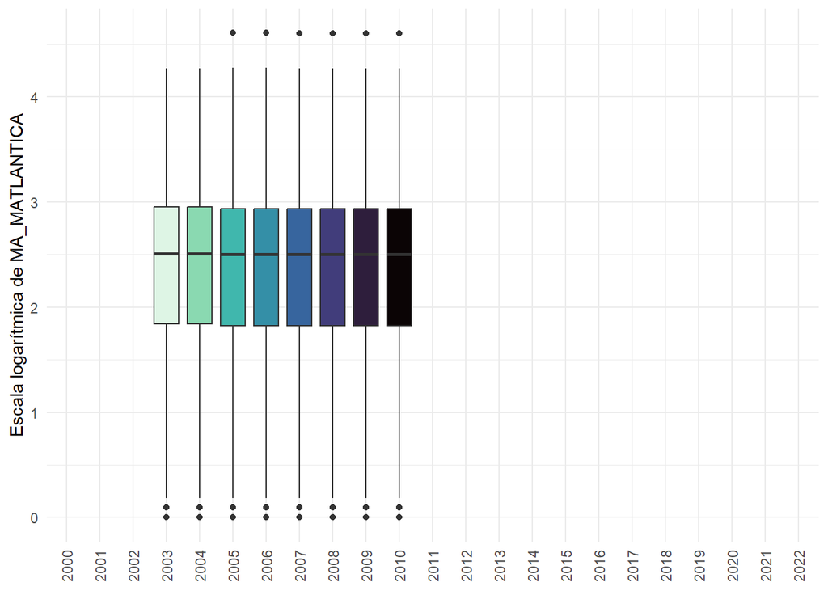

#### MA_AIIGENA

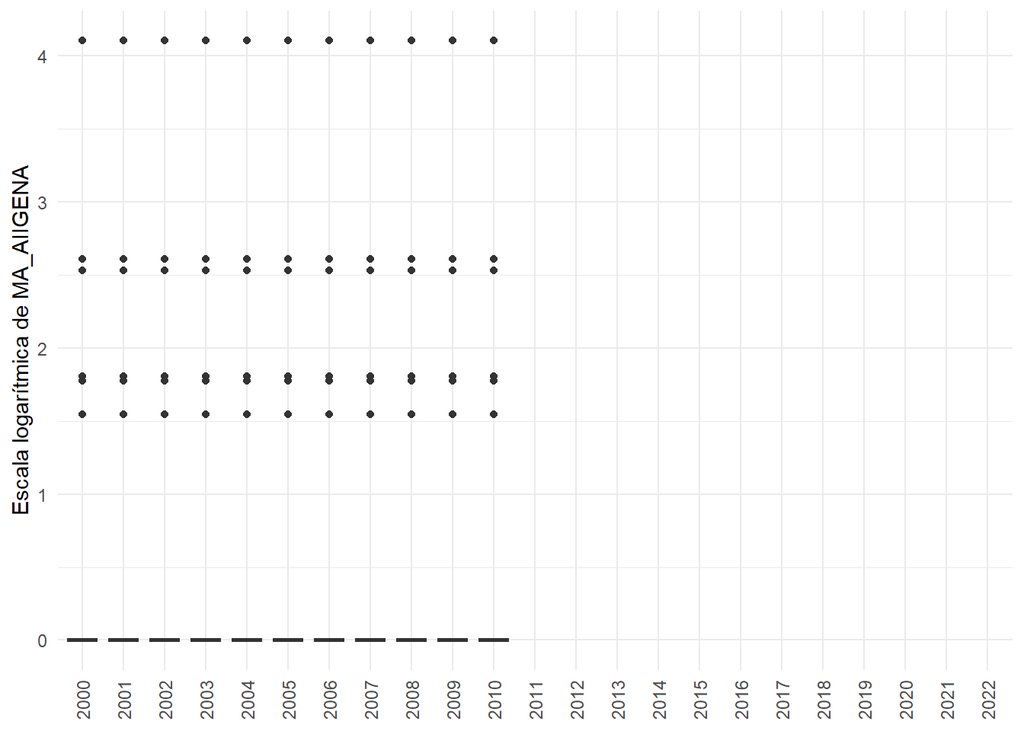

#### MA_PROINTEGRAL

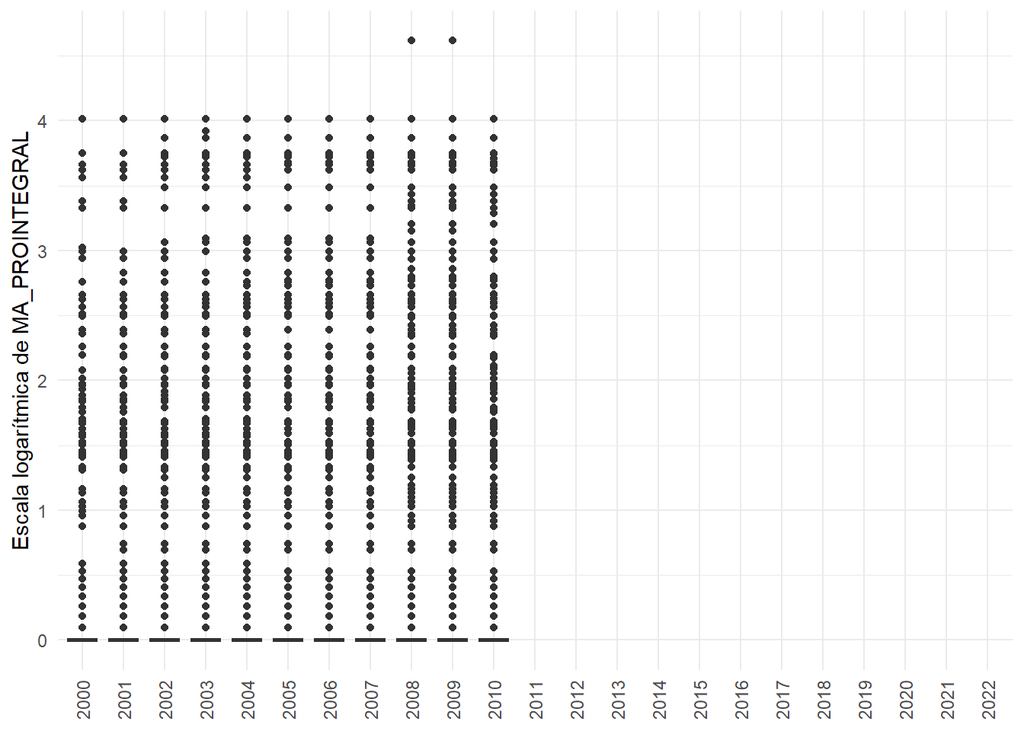

#### MA_USOSUST

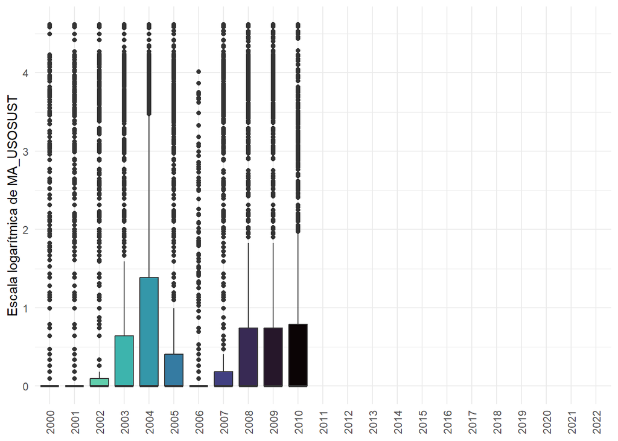

#### MA_ICMSECOLOG

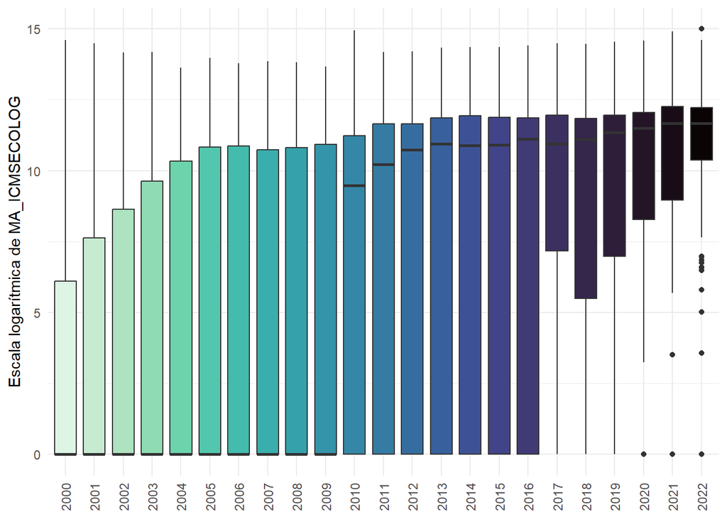

#### MA_CRH

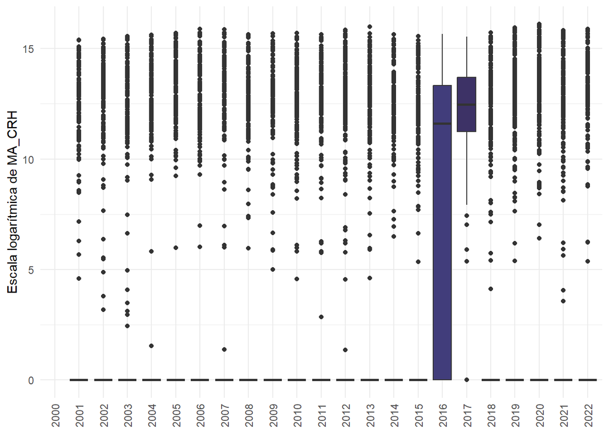

#### MA_CFEM

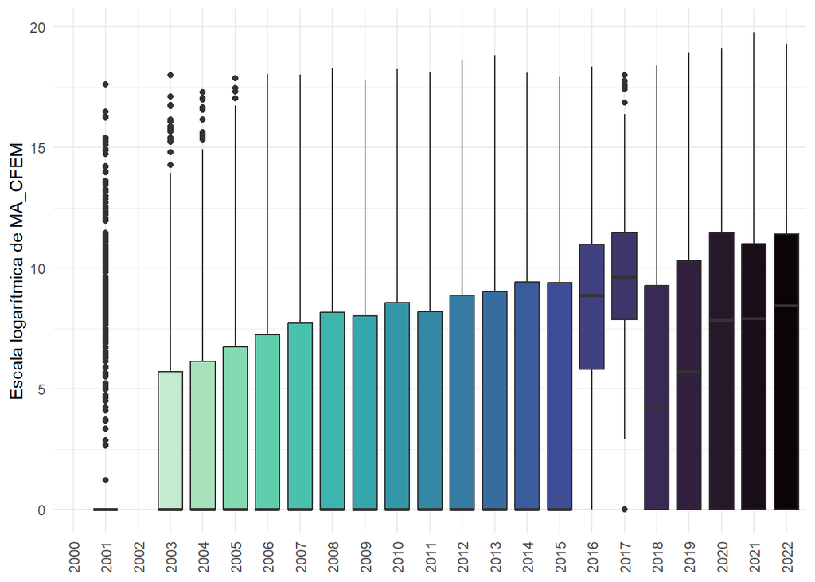

#### MA_FOCOS

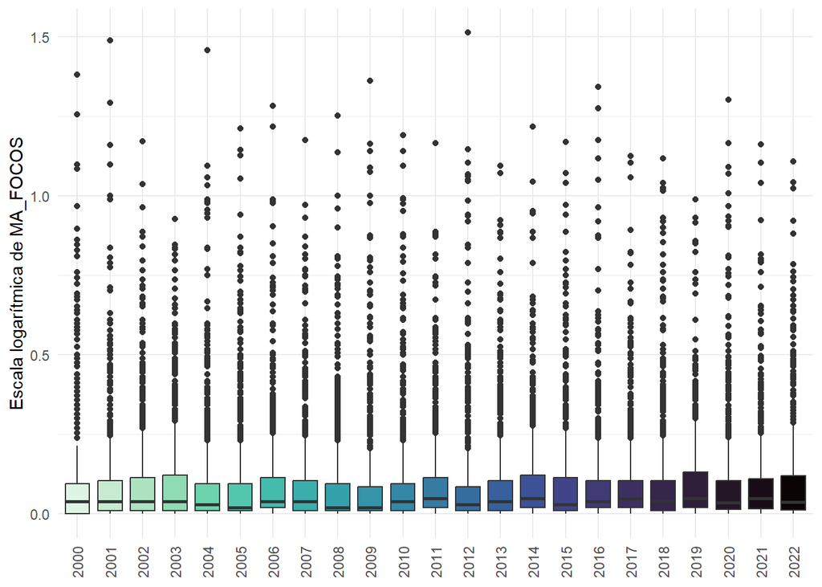

#### MA_CANA

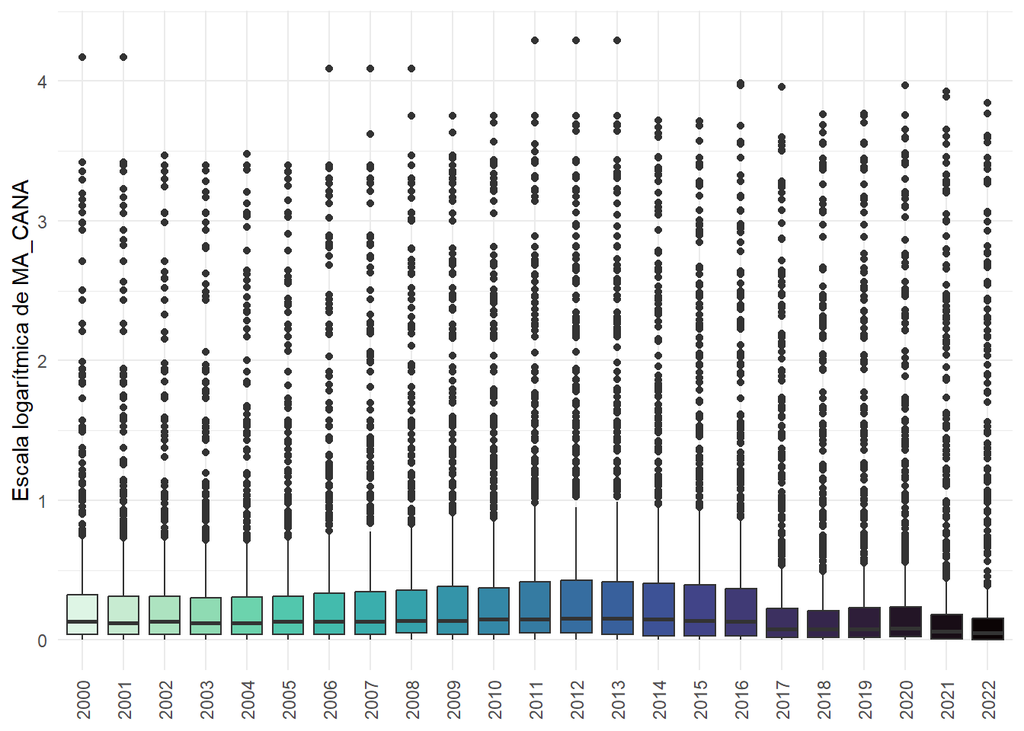

#### MA_FROTA

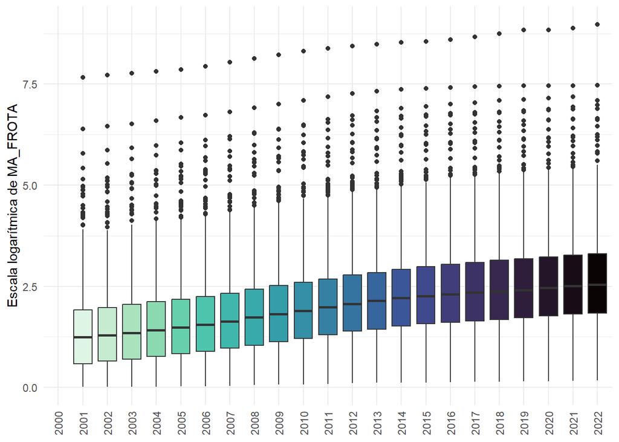

#### MA_BOVINO

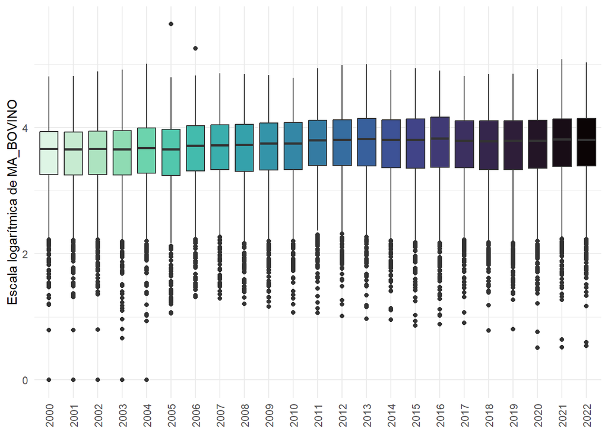

#### MA_REFLO

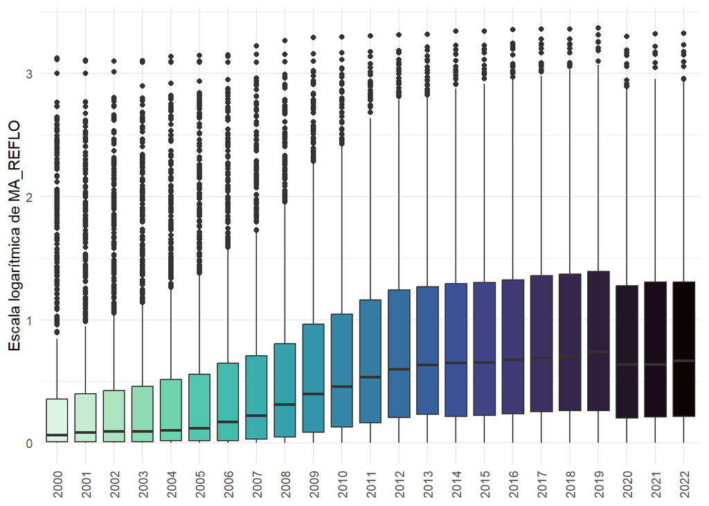

#### MA_FLONATIVA

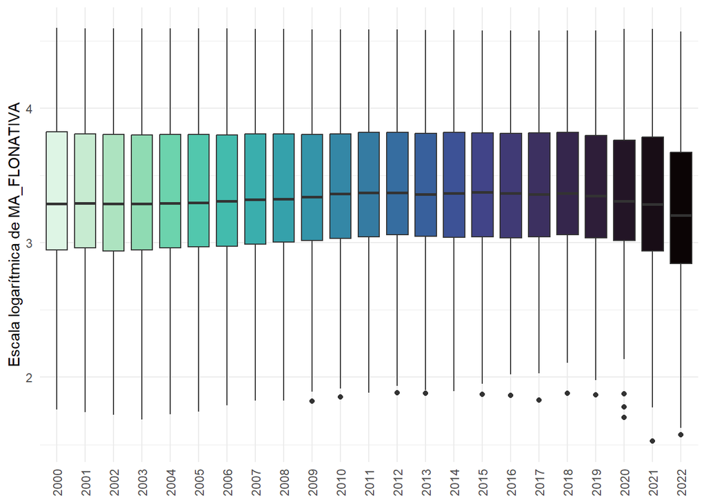

#### MA_INFRA

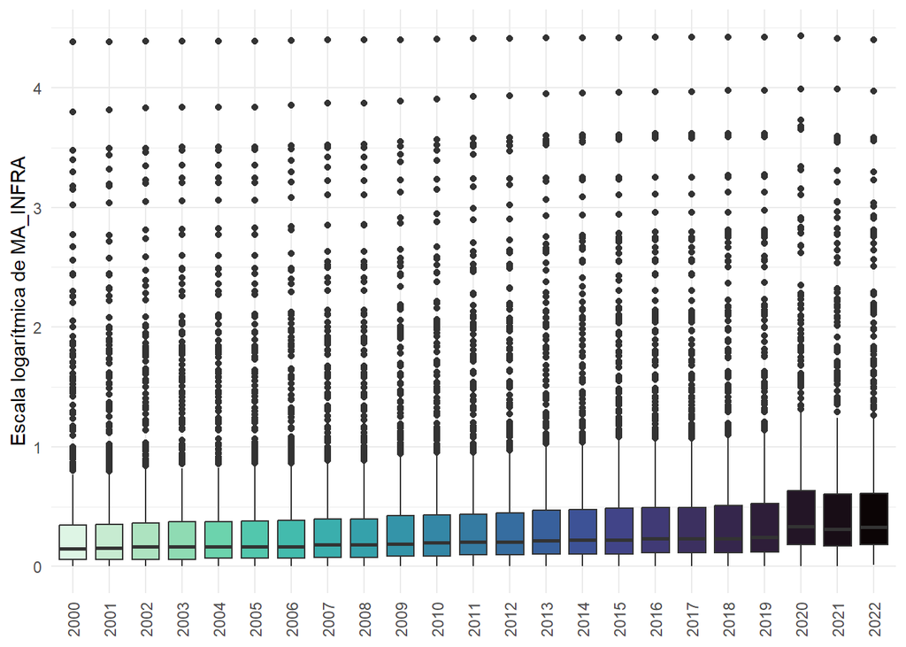

#### MA_AGRO

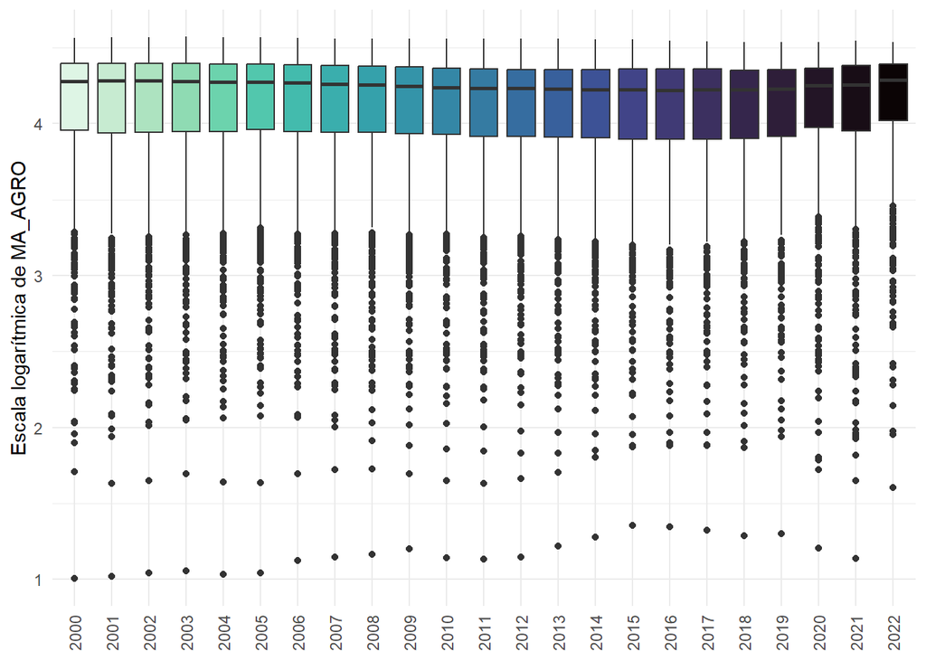

### Histograma

#### MA_MATLANTICA

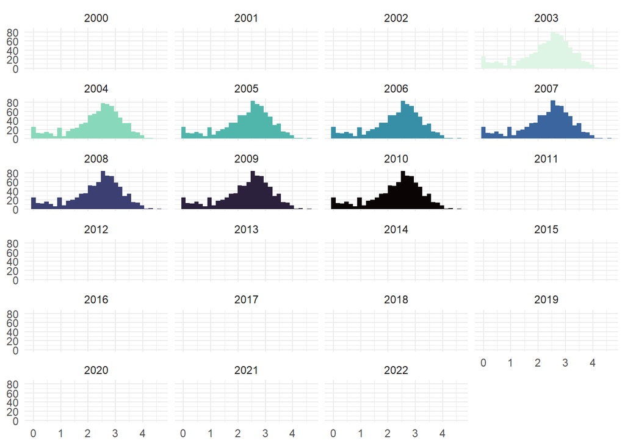

#### MA_AIIGENA

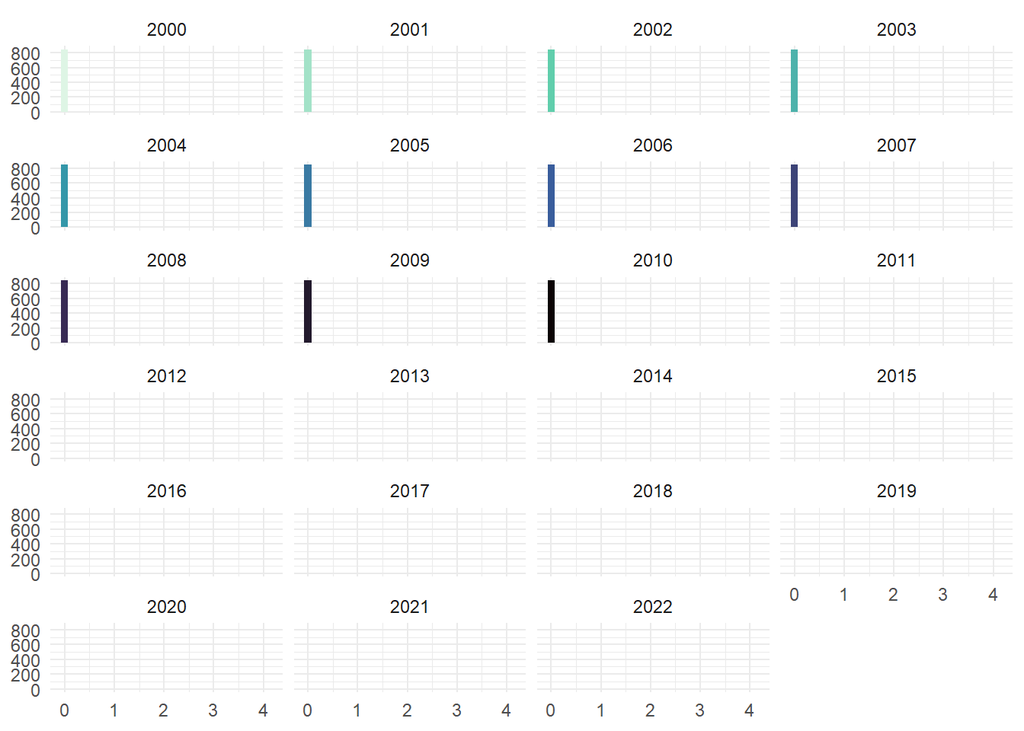

#### MA_PROINTEGRAL

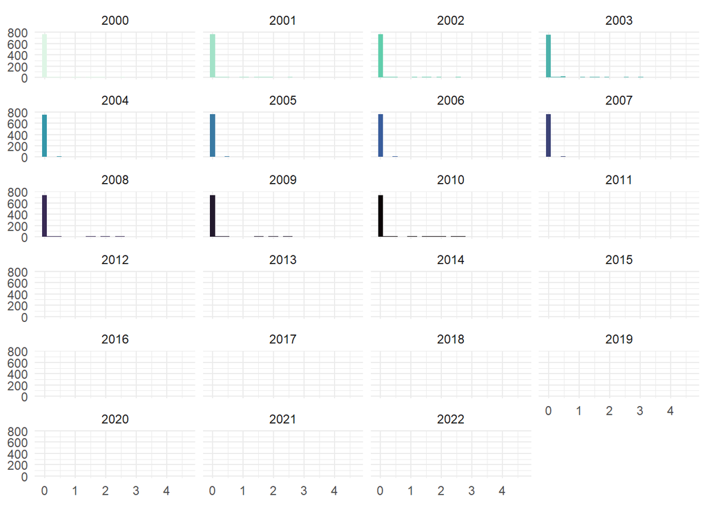

#### MA_USOSUST

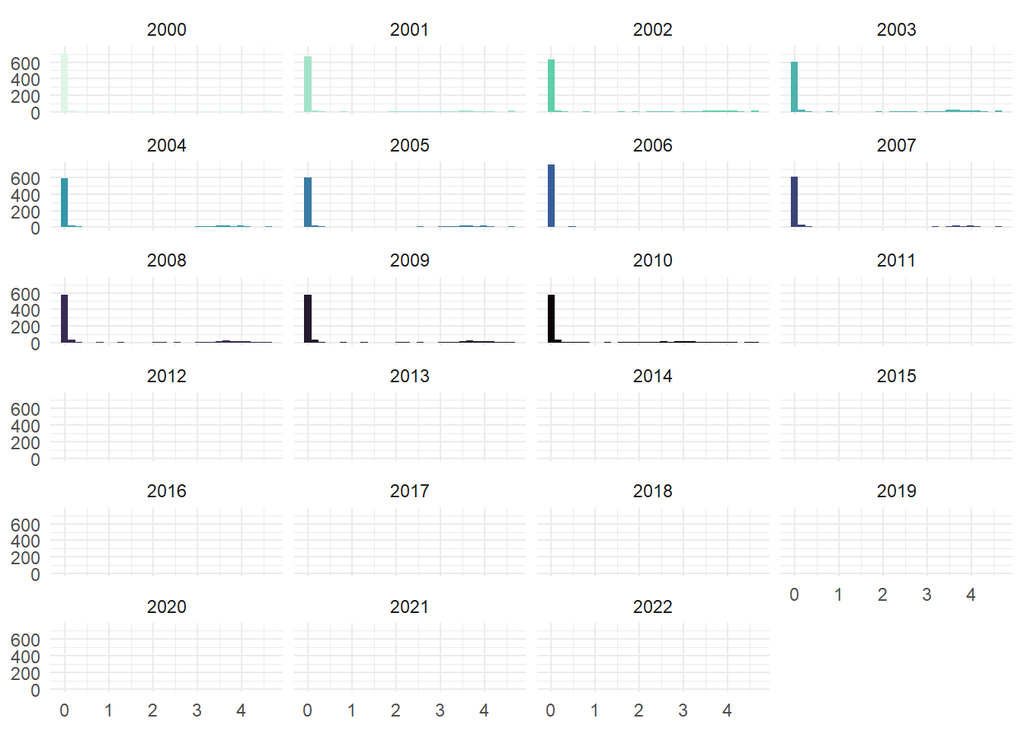

#### MA_ICMSECOLOG

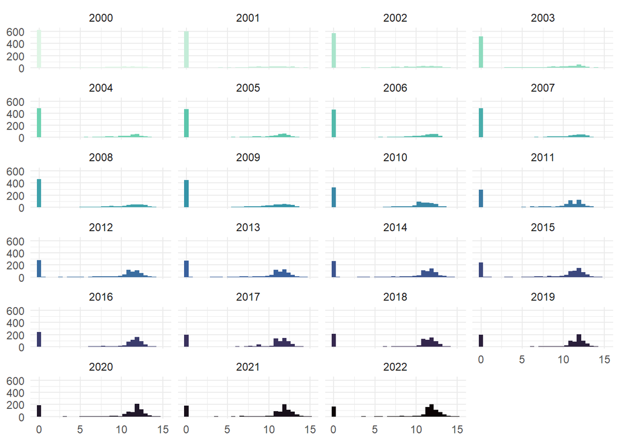

#### MA_CRH

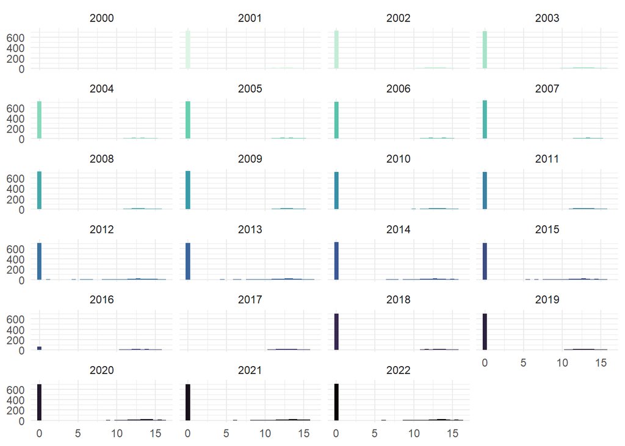

#### MA_CFEM

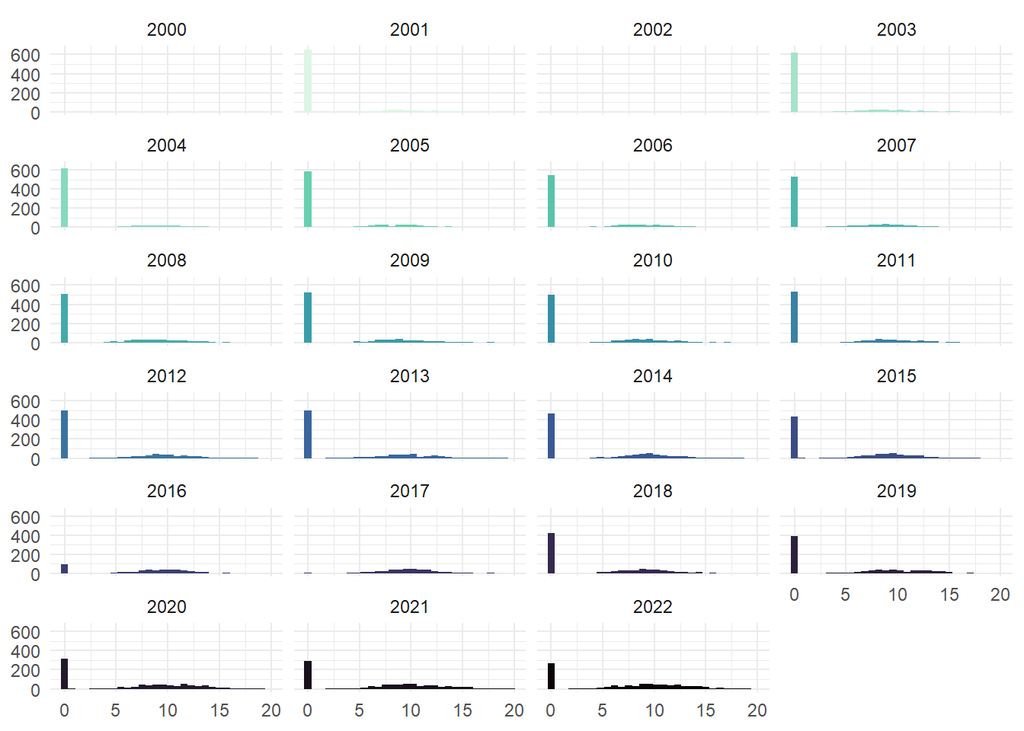

#### MA_FOCOS

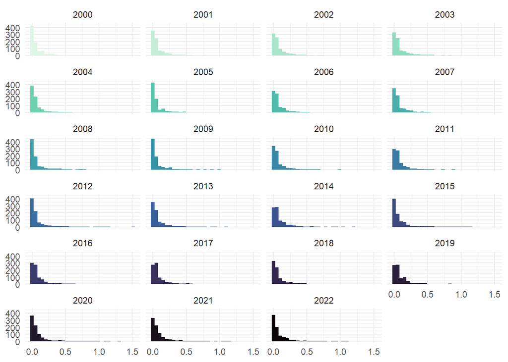

#### MA_CANA

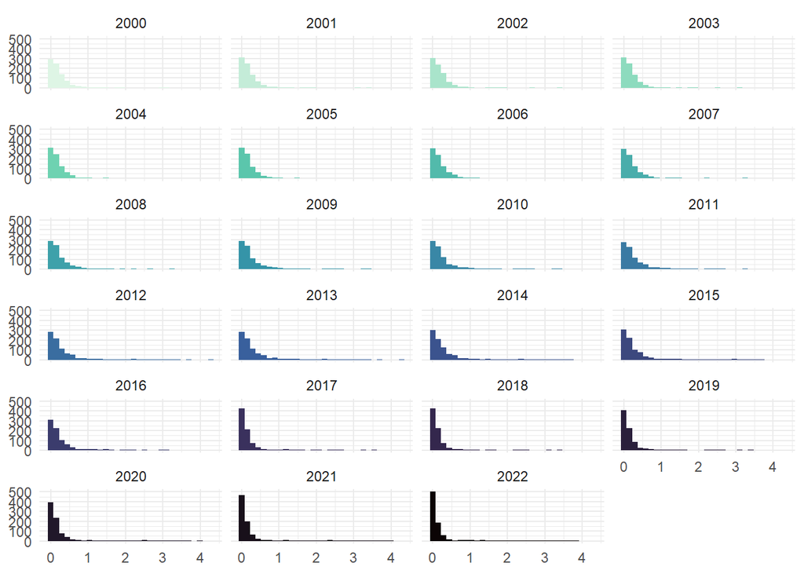

#### MA_FROTA

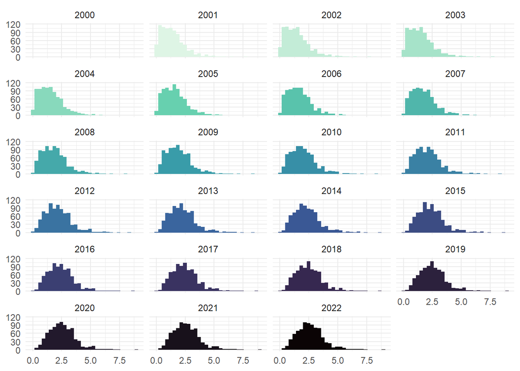

#### MA_BOVINO

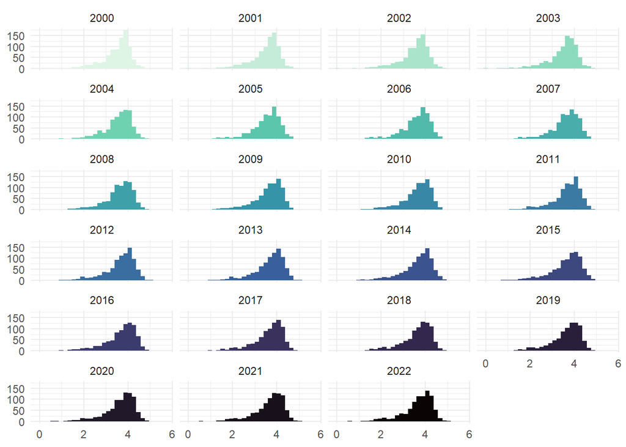

#### MA_REFLO

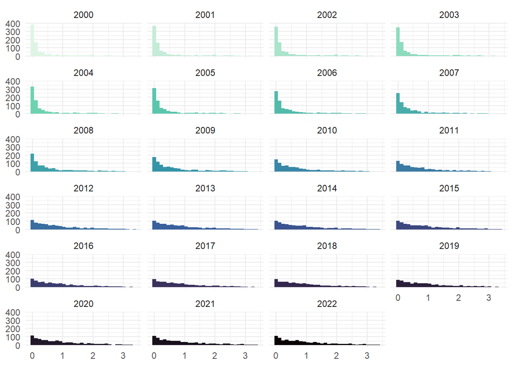

#### MA_FLONATIVA

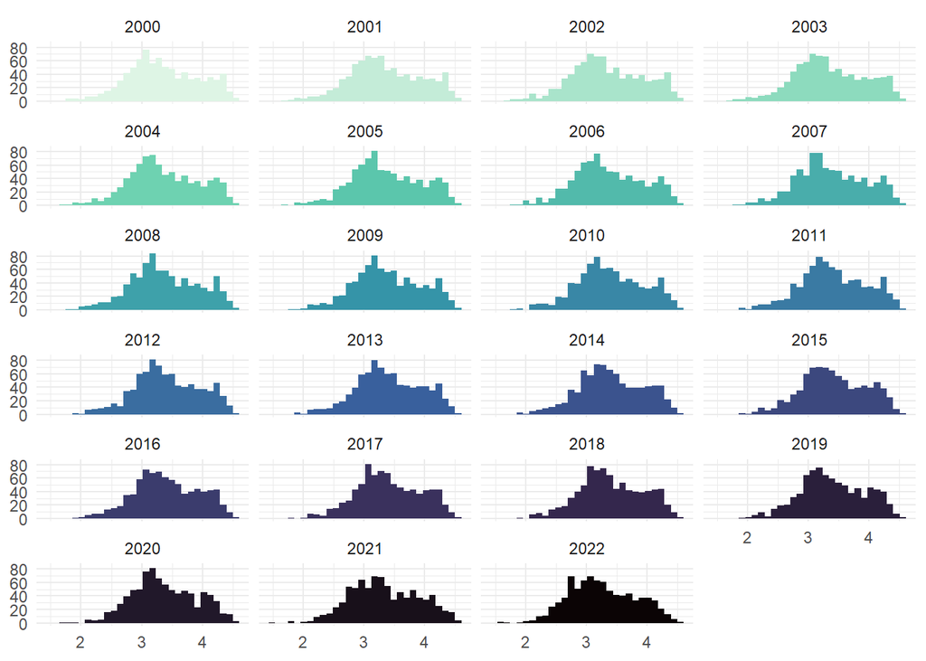

#### MA_INFRA

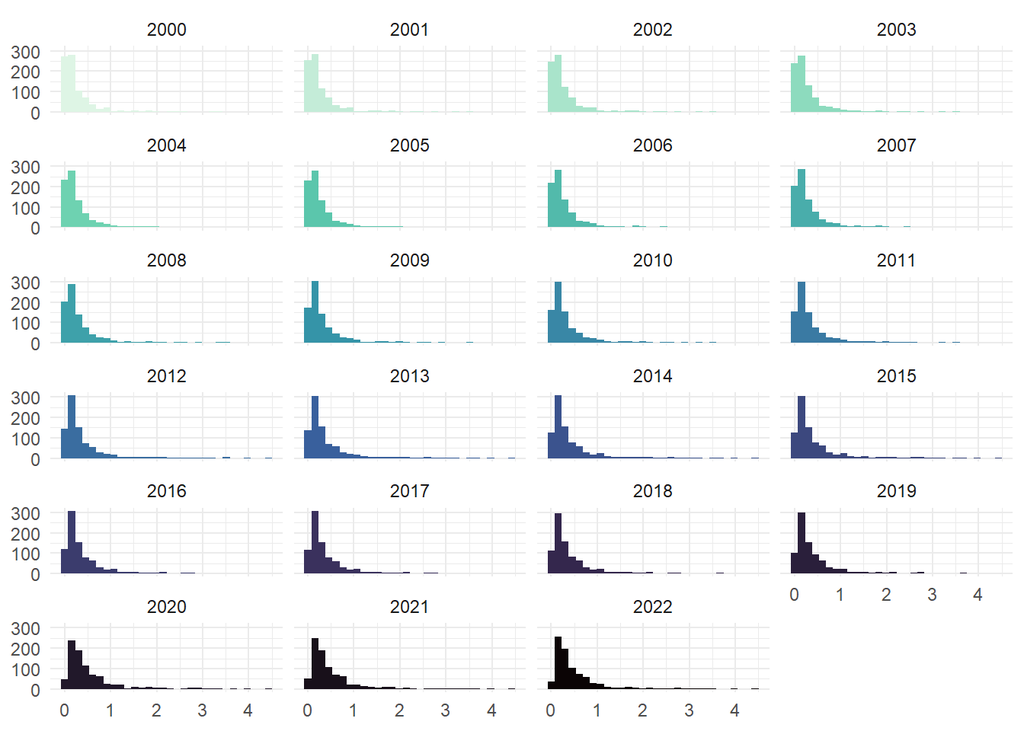

#### MA_AGRO

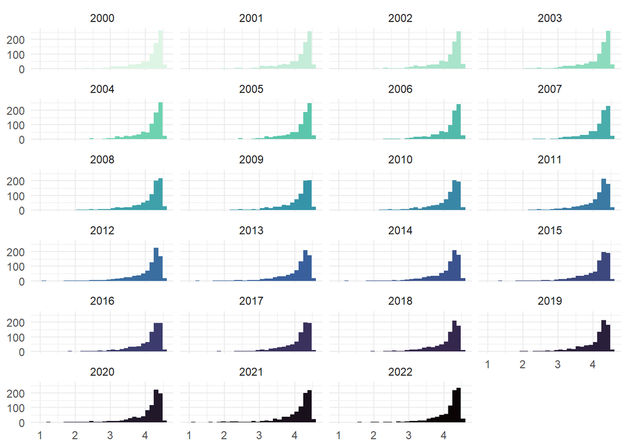